# Reproducible Research Assessment 1

Kanako Sobajima

14 October 2015

## Loading and preprocessing the data

```r
if(!file.exists("activity.csv") ){
unzip("repdata-data-activity.zip")}

act <- read.csv("activity.csv", stringsAsFactor=FALSE)
```

## What is mean total number of steps taken per day?

#### 1. Calculate the total number of steps taken per day

```r
actdata <- act[with (act, {!(is.na(steps))}),]
steps <- as.numeric (actdata$steps)

steps_day <- aggregate(steps, list(actdata$date),sum)
colnames(steps_day) <- c ("date", "steps")
head(steps_day,3)
```

```
##         date steps
## 1 2012-10-02   126
## 2 2012-10-03 11352
## 3 2012-10-04 12116
```

#### 2. A histogram of the total number of steps per day

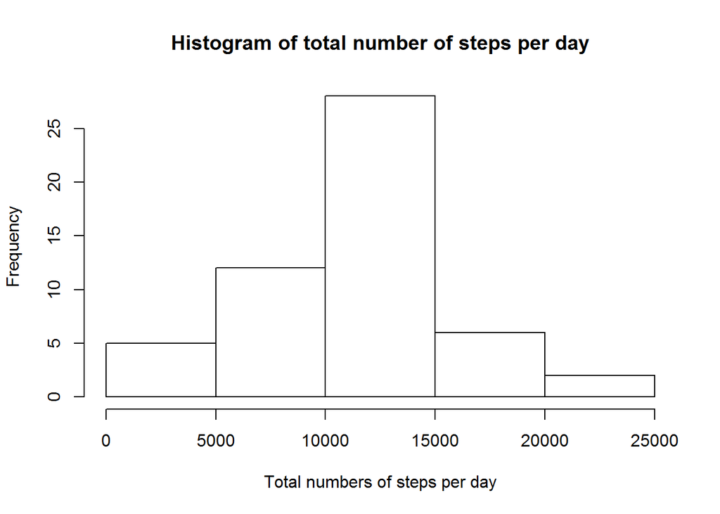

```r
hist (steps_day$steps, main = "Histogram of total number of steps per day",
     xlab = "Total numbers of steps per day")
```

#### 3. Show the mean and median of the total number of steps per day

```r
summary (steps_day)
```

```
##      date               steps
##  Length:53          Min.   :   41
##  Class :character   1st Qu.: 8841
##  Mode  :character   Median :10765
##                     Mean   :10766
##                     3rd Qu.:13294
##                     Max.   :21194
```

The mean total number of steps per day is 10766 and the median total number of steps per day is 10765.

## What is the average daily activity pattern?

#### 1. Time series plot (`type = "l"`) of the five-minute interval vs the average number of steps taken, averaged across all day

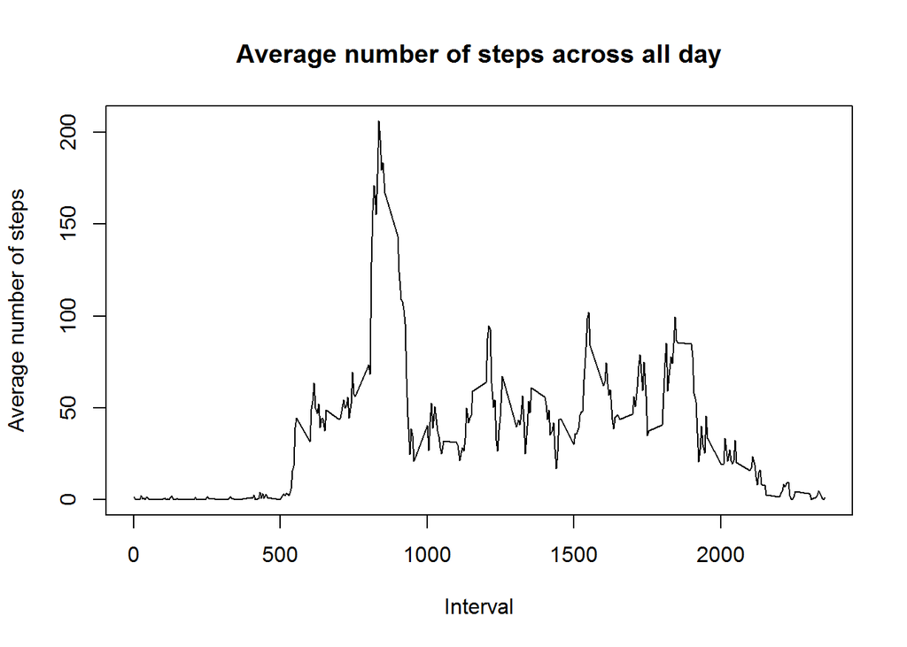

```r
interval<- as.numeric (actdata$interval)
steps_interval <- aggregate(steps ~ interval, actdata, mean)

plot (steps_interval$interval, steps_interval$steps, type="l",
      main = "Average number of steps across all day",
      xlab = "Interval",
      ylab = "Average number of steps")
```

#### 2. Find the interval with the maximum number of steps

```r
interval_desc <- steps_interval [order (steps_interval$steps,decreasing = TRUE),]
max_interval <- interval_desc[1,]
max_interval
```

```
##     interval    steps
## 104      835 206.1698
```

The interval with the maximum number of steps is 835 with 206.1698 steps

## Imputing missing values

#### 1.Identify the total number of rows with `NA`s

```r
sum(is.na(act))
```

```
## [1] 2304
```

The total number of rows with `NA`s is 2304

#### 2. Replace `NA`s to the average daily activity pattern and

#### 3. Create a new dataset with no `NA`s

Used the average daily activity pattern for replacing `NA`s to some values because there are the days with no values for steps (e.g. 2010-10-01).

```r
act_nona <- act
for (i in 1:nrow(act_nona)){
  if(is.na(act_nona$steps[i])){
    interval_row <- act_nona$interval[i]
    steps_row <- steps_interval[steps_interval$interval == interval_row,]
    act_nona$steps[i] <- steps_row$steps
  }
}
```

Check if there are no `NA`s

```r
sum(is.na(act_nona))
```

```
## [1] 0
```

#### 4-1. A histogram of the total number of steps per day

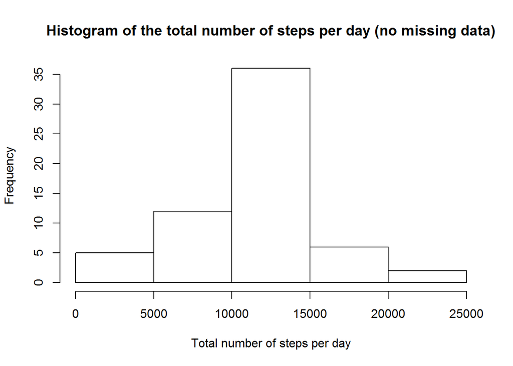

```r
nona_steps_day <- aggregate(steps ~date, act_nona, sum)

hist(nona_steps_day$steps,
     main = "Histogram of the total number of steps per day (no missing data)",
     xlab = "Total number of steps per day")
```

#### 4-2. Show the mean and median of the total number of steps per day

```r
summary (nona_steps_day)
```

```
##      date               steps
##  Length:61          Min.   :   41
##  Class :character   1st Qu.: 9819
##  Mode  :character   Median :10766
##                     Mean   :10766
##                     3rd Qu.:12811
##                     Max.   :21194
```

The mean total number of steps per day is 10766 and the median total number of steps per day is 10766.

**What is the impact of imputing missing data on the estimates of the total daily number of steps?**

The summary of output before imputing missing data

```r
summary (steps_day)
```

```
##      date               steps
##  Length:53          Min.   :   41
##  Class :character   1st Qu.: 8841
##  Mode  :character   Median :10765
##                     Mean   :10766
##                     3rd Qu.:13294
##                     Max.   :21194
```

## Are there differences in activity patterns between weekdays and weekends?

#### 1. Add a new variable with two levels (weekday and weekend) to the dataframe which indicates wheter a given date is a weekday or weekend day

```r
act_nona [, "day"] <- weekdays(as.Date(act_nona$date))
act_nona [,"day"] <- gsub("Saturday|Sunday", "weekend", act_nona$day)
act_nona [,"day"] <- gsub("Monday|Tuesday|Wednesday|Thursday|Friday", "weekday", act_nona$day)
act_nona[,"day"] <- as.factor(act_nona[,"day"])
```

#### 2. A panel plot with a time series plot (`type = "l"`) of the five-minute interval vs the average number of steps taken acrooss all weekdays or weekends.

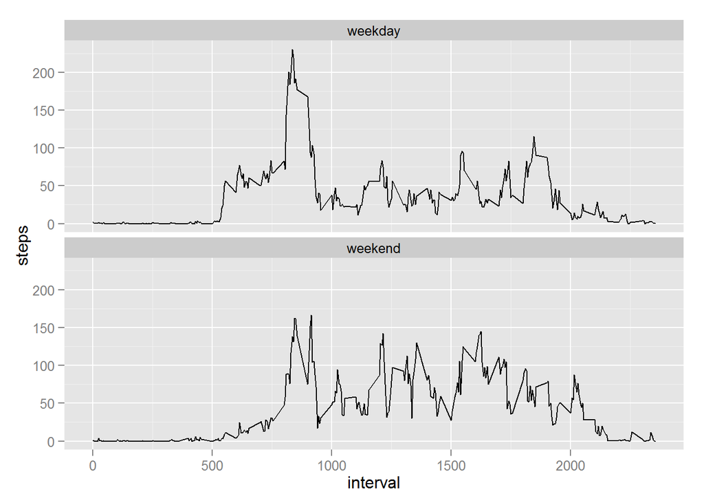

```r
nona_steps_int_days <- aggregate (steps ~interval + day, act_nona, mean)

library (ggplot2)
ggplot(data = nona_steps_int_days,
       aes(x= interval, y= steps ))+
  geom_line()+
  facet_wrap(~day, ncol = 1)
```